# Week5 : Tree Based Methods

### Objectives

This homework sheet will help reviewing the basic concepts associated with tree-based methods and provide a basic introduction to the ML workflow using real-world datasets. Please review the lectures, suggested readings, and additional resources *before* getting started on the HW.

**Some questions in this assignment will require you to conduct independent research beyond the material covered in the recorded content.**

The following website has access to the relevant datasets from the recommended textbook: https://book.huihoo.com/introduction-to-statistical-learning/data.html

Marks Distribution

| Question | Marks |
| --- | --- |
| 1 | 3 |
| 2 | 3 |
| 3a | 2 |
| 3b | 2 |
| 3c | 5 |

# Questions

Conceptual

Q1. Draw an example (of your own invention) of a partition of two-dimensional feature space that could result from recursive binary splitting. Your example should contain at least six regions. Draw a decision tree corresponding to this partition. Be sure to label all aspects of your figures, including the regions $R_1$, $R_2$, ... , the cutpoints $t_1$ , $t_2$, ..., and so forth. Please insert your sketch below.

**Please note: You can use Microsoft word / any editor or draw the image by hand, you can upload the image / screenshot to colab file using insert image option in text cell**

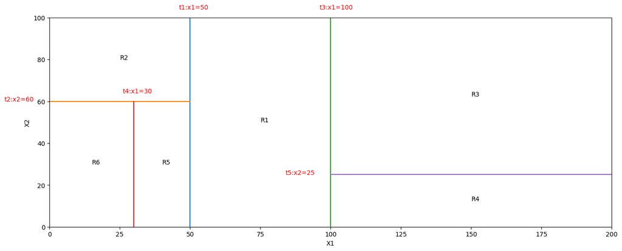

```python
import matplotlib.pyplot as plt
import numpy as np

X1_range = [0, 200]
X2_range = [0, 100]
X1_length = X1_range[1] - X1_range[0]
X2_length = X2_range[1] - X2_range[0]

# Define the cut points
t1_x1 = 50
t2_x2 = 60
t3_x1 = 100
t4_x1 = 30
t5_x2 = 25

plt.figure(figsize=(16, 6))
plt.xlim(0, X1_length)
plt.ylim(0, X2_length)
plt.xlabel('X1')
plt.ylabel('X2')

def plot_vertical_split(t_label, t, range, label_color='red'):
    plt.plot([t, t], range)
    plt.text(t-4, range[1] + 4, f'{t_label}:x1={t}', color='red')



def plot_horizontal_split(t_label, t, range, label_color='red'):
    plt.plot(range, [t, t])
    plt.text(range[0]-16, t, f'{t_label}:x2={t}', color='red')

plot_vertical_split('t1', t1_x1, X2_range)
plot_horizontal_split('t2', t2_x2, [X1_range[0], t1_x1])
plot_vertical_split('t3', t3_x1, X2_range)
plot_vertical_split('t4', t4_x1, [X2_range[0],t2_x2])
plot_horizontal_split('t5', t5_x2, [t3_x1, X1_range[1]])

plt.text((t1_x1 + t3_x1) / 2, X2_length/2, 'R1')
# plt.text(20, (100 + 75) / 2, 'R2')
plt.text(X1_range[0] + t1_x1/2, (t2_x2 + (X2_range[1] - t2_x2)/2), 'R2')
plt.text(t3_x1 + (X1_range[1] - t3_x1)/2, t5_x2 + (X2_range[1] - t5_x2)/2, 'R3')
plt.text(t3_x1 + (X1_range[1] - t3_x1)/2, X2_range[0] + (t5_x2 - X2_range[0])/2, 'R4')
plt.text(t4_x1 + (t1_x1-t4_x1)/2, X2_range[0] + t2_x2/2, 'R5')
plt.text(X1_range[0] + t4_x1/2, X2_range[0] + t2_x2/2, 'R6')

plt.show()
```

[figure not shown]

# ANSWER in the markdown cell

Q2. Suppose we produce ten bootstrapped samples from a data set containing red and green classes. We then apply a classification tree to each bootstrapped sample and, for a specific value of $X$, produce $10$ estimates of $P(Class is Red|X)$:

$0.1$, $0.15$, $0.2$, $0.2$, $0.55$, $0.6$, $0.6$, $0.65$, $0.7$, and $0.75$.

There are two common ways to combine these results together into a single class prediction. One is the majority vote approach , the second approach is to classify based on the average probability. In this example, what is the final classification under each of these two approaches?

### Majority Vore Approach

| $P(Class = Red | X)$ |
| --- | --- |
| $0.1$ | Green |
| $0.15$ | Green |
| $0.2$ | Green |
| $0.2$ | Green |
| $0.55$ | Red |
| $0.6$ | Red |
| $0.6$ | Red |
| $0.65$ | Red |
| $0.7$ | Red |
| $0.75$ | Red |

Hence the Vote for Red is 6 and 4 for Green. Hence the Final classification under majority vote approach approch is **Red**

### Average Probability Method.

The average probabilty is given by $$ P_{\text{avg}}(\text{Class is Red}|X) = \frac{1}{10} \sum_{i=1}^{10} P_i(\text{Class is Red}|X) $$ where $P_i(\text{Class is Red}|X)$ represents the probability of the class being red for the $i$-th estimator.

Here

$$ P_{\text{avg}}(\text{Class is Red}|X) = \frac{0.1 + 0.15 + 0.2 + 0.2 + 0.55 + 0.6 + 0.6 + 0.65 + 0.7 + 0.75}{10} = 0.45 $$

So, under the average probability approach, the final classification would be green as 0.45 < 0.5 .

# APPLIED

Q3. Apply boosting and random forest to a data set of your choice. Feel free to use any of the datasets from ISLR dataset link provided ( https://book.huihoo.com/introduction-to-statistical-learning/data.html ) to examine any of the questions that were discussed in any of the previous homeworks. Be sure to fit the models on a training set and to evaluate their performance on a test set. How accurate are the results compared to simple methods (e.g. linear or logistic regression models)? Which of these approaches yields the best performance?

#### ANSWER

```python
# import libraries
import pandas as pd
import statsmodels.api as sm
import seaborn as sns
import warnings
from sklearn.model_selection import train_test_split
from sklearn.linear_model import LinearRegression
from sklearn.ensemble import GradientBoostingRegressor, RandomForestRegressor
from sklearn.metrics import r2_score

warnings.filterwarnings("ignore")
```

```python
# FILENAME = "auto.csv"
# df = sm.datasets.get_rdataset('Auto', 'ISLR').data
# df.to_csv(FILENAME, index=False)
```

#### a) Read the dataset using function read_csv( ) from pandas library and preprocess the data if required ( check for any missing values etc )

```python
df = pd.read_csv("Auto.csv")
df.head(10)
```

|  | mpg | cylinders | displacement | horsepower | weight | acceleration | year | origin | name |
| --- | --- | --- | --- | --- | --- | --- | --- | --- | --- |
| 0 | 18.0 | 8 | 307.0 | 130 | 3504 | 12.0 | 70 | 1 | chevrolet chevelle malibu |
| 1 | 15.0 | 8 | 350.0 | 165 | 3693 | 11.5 | 70 | 1 | buick skylark 320 |
| 2 | 18.0 | 8 | 318.0 | 150 | 3436 | 11.0 | 70 | 1 | plymouth satellite |
| 3 | 16.0 | 8 | 304.0 | 150 | 3433 | 12.0 | 70 | 1 | amc rebel sst |
| 4 | 17.0 | 8 | 302.0 | 140 | 3449 | 10.5 | 70 | 1 | ford torino |
| 5 | 15.0 | 8 | 429.0 | 198 | 4341 | 10.0 | 70 | 1 | ford galaxie 500 |
| 6 | 14.0 | 8 | 454.0 | 220 | 4354 | 9.0 | 70 | 1 | chevrolet impala |
| 7 | 14.0 | 8 | 440.0 | 215 | 4312 | 8.5 | 70 | 1 | plymouth fury iii |
| 8 | 14.0 | 8 | 455.0 | 225 | 4425 | 10.0 | 70 | 1 | pontiac catalina |
| 9 | 15.0 | 8 | 390.0 | 190 | 3850 | 8.5 | 70 | 1 | amc ambassador dpl |

```python
df.info()
```

```
<class 'pandas.core.frame.DataFrame'>
RangeIndex: 397 entries, 0 to 396
Data columns (total 9 columns):
 #   Column        Non-Null Count  Dtype
---  ------        --------------  -----
 0   mpg           397 non-null    float64
 1   cylinders     397 non-null    int64
 2   displacement  397 non-null    float64
 3   horsepower    397 non-null    object
 4   weight        397 non-null    int64
 5   acceleration  397 non-null    float64
 6   year          397 non-null    int64
 7   origin        397 non-null    int64
 8   name          397 non-null    object
dtypes: float64(3), int64(4), object(2)
memory usage: 28.0+ KB
```

```python
df["horsepower"] = pd.to_numeric(df["horsepower"], errors="coerce")
df.isnull().sum()
```

```
mpg             0
cylinders       0
displacement    0
horsepower      5
weight          0
acceleration    0
year            0
origin          0
name            0
dtype: int64
```

Here 5 values are missing for horsepower

```python
df = df.dropna()
```

```python
df.describe(include='all')
```

|  | mpg | cylinders | displacement | horsepower | weight | acceleration | year | origin | name |
| --- | --- | --- | --- | --- | --- | --- | --- | --- | --- |
| count | 392.000000 | 392.000000 | 392.000000 | 392.000000 | 392.000000 | 392.000000 | 392.000000 | 392.000000 | 392 |
| unique | NaN | NaN | NaN | NaN | NaN | NaN | NaN | NaN | 301 |
| top | NaN | NaN | NaN | NaN | NaN | NaN | NaN | NaN | amc matador |
| freq | NaN | NaN | NaN | NaN | NaN | NaN | NaN | NaN | 5 |
| mean | 23.445918 | 5.471939 | 194.411990 | 104.469388 | 2977.584184 | 15.541327 | 75.979592 | 1.576531 | NaN |
| std | 7.805007 | 1.705783 | 104.644004 | 38.491160 | 849.402560 | 2.758864 | 3.683737 | 0.805518 | NaN |
| min | 9.000000 | 3.000000 | 68.000000 | 46.000000 | 1613.000000 | 8.000000 | 70.000000 | 1.000000 | NaN |
| 25% | 17.000000 | 4.000000 | 105.000000 | 75.000000 | 2225.250000 | 13.775000 | 73.000000 | 1.000000 | NaN |
| 50% | 22.750000 | 4.000000 | 151.000000 | 93.500000 | 2803.500000 | 15.500000 | 76.000000 | 1.000000 | NaN |
| 75% | 29.000000 | 8.000000 | 275.750000 | 126.000000 | 3614.750000 | 17.025000 | 79.000000 | 2.000000 | NaN |
| max | 46.600000 | 8.000000 | 455.000000 | 230.000000 | 5140.000000 | 24.800000 | 82.000000 | 3.000000 | NaN |

```python
print("The number of missing values are")
df.isnull().sum()
```

```
The number of missing values are
```

```
mpg             0
cylinders       0
displacement    0
horsepower      0
weight          0
acceleration    0
year            0
origin          0
name            0
dtype: int64
```

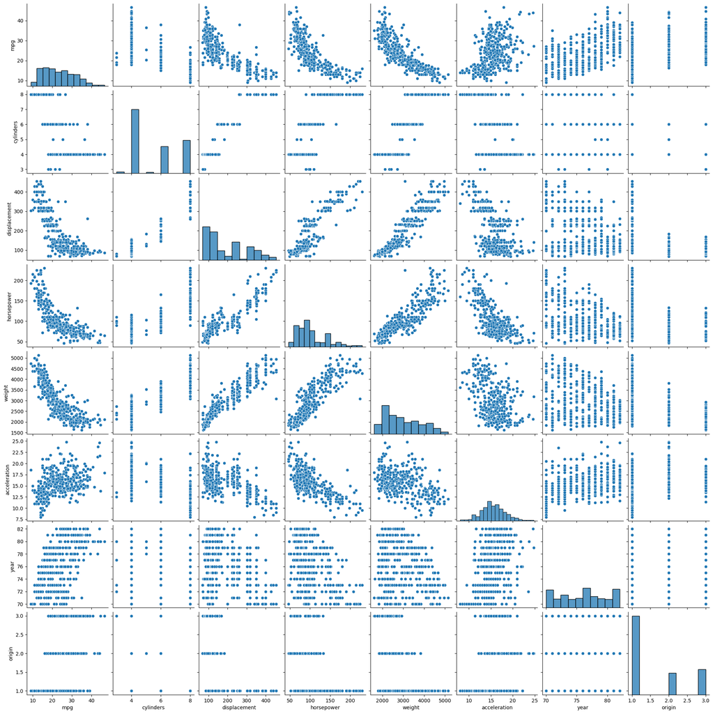

```python
sns.pairplot(data=df)
```

#### b) Split the data into train data and test data ( proportion of train and test data of your choice )

Reference :

https://scikit-learn.org/stable/modules/generated/sklearn.model_selection.train_test_split.html

```python
X = df.drop(columns=['mpg', 'name'])
y = df['mpg']
X_train_, X_test_, y_train, y_test = train_test_split(X, y, test_size=0.2, random_state=42)
from sklearn.preprocessing import StandardScaler
sc = StandardScaler()
x_train = sc.fit_transform(X_train_)
X_train = pd.DataFrame(x_train, columns = X_train_.columns)
x_test = sc.transform(X_test_)
X_test = pd.DataFrame(x_test, columns=X_test_.columns)
```

#### c) Train the data on the below models

1. Linear regression model
2. Gradient boosting model
3. Random forest model

check the train and test r2 score and mention your findings on which model performed better in terms of underfitting / overfitting etc

References:

https://scikit-learn.org/stable/modules/generated/sklearn.linear_model.LinearRegression.html

https://scikit-learn.org/stable/auto_examples/ensemble/plot_gradient_boosting_regression.html#gradient-boosting-regression

https://scikit-learn.org/stable/modules/generated/sklearn.ensemble.RandomForestRegressor.html

https://scikit-learn.org/stable/modules/generated/sklearn.metrics.r2_score.html

```python
# Linear Regression model
lr_model = LinearRegression()
lr_model.fit(X_train, y_train)
lr_train_r2 = r2_score(y_train, lr_model.predict(X_train))
lr_test_r2 = r2_score(y_test, lr_model.predict(X_test))

# Gradient Boosting model
gb_model = GradientBoostingRegressor(n_estimators=100, random_state=27)
gb_model.fit(X_train, y_train)
gb_train_r2 = r2_score(y_train, gb_model.predict(X_train))
gb_test_r2 = r2_score(y_test, gb_model.predict(X_test))

# Random Forest model
rf_model = RandomForestRegressor(n_estimators=100, random_state=27)
rf_model.fit(X_train, y_train)
rf_train_r2 = r2_score(y_train, rf_model.predict(X_train))
rf_test_r2 = r2_score(y_test, rf_model.predict(X_test))

# Print the R2 scores
print("Linear Regression - Train R2:", lr_train_r2, "Test R2:", lr_test_r2, "Difference: ", lr_train_r2-lr_test_r2)
print("Gradient Boosting - Train R2:", gb_train_r2, "Test R2:", gb_test_r2, "Difference: ", gb_train_r2-gb_test_r2)
print("Random Forest - Train R2:", rf_train_r2, "Test R2:", rf_test_r2, "Difference: ", rf_train_r2-rf_test_r2)
```

```
Linear Regression - Train R2: 0.826001578671067 Test R2: 0.7901500386760347 Difference:  0.03585153999503232
Gradient Boosting - Train R2: 0.9705756218684116 Test R2: 0.8803791129828579 Difference:  0.09019650888555375
Random Forest - Train R2: 0.9828033958508994 Test R2: 0.8905103584280339 Difference:  0.09229303742286543
```